# Семинар 4.

# Статистические критерии

## Теория

Статистический критерий — это правило, позволяющее на основании выборочных данных принять или отклонить статистическую гипотезу. Работа статистического критерия включает следующие этапы:

### 1. Модель

Строится утверждение о распределении данных

### 2. Формулировка гипотез

Нулевая гипотеза ($H_0$): базовое предположение, которое проверяется (например, "средний рост мужчин и женщин одинаков").

Альтернативная гипотеза ($H_1$): гипотеза, противоречащая нулевой (например, "средний рост мужчин и женщин различается").

Гипотеза формулируется на математическом языке через характеристики случайной величины.

### 3. Выбор уровня значимости $\alpha$

Это вероятность ошибочного отклонения $H_0$, если она на самом деле верна

### 4. Выбор статистического критерия

В зависимости от типа данных, размера выборки и задачи (например, сравнение средних, проверка на корреляцию, тест на распределение) выбирается соответствующий критерий

### 5. Вычисление статистики критерия

Рассчитывается значение тестовой статистики по формуле, зависящей от выбранного критерия.

### 6. Определение критической области

Определяется диапазон значений тестовой статистики, при которых H₀ отклоняется

### 7. Принятие решения

Если вычисленная статистика попадает в критическую область $H_0$ отвергается в пользу $H_1$.

Если нет, то $H_0$ не отвергается.

p-value (уровень значимости наблюдаемого результата) — это вероятность получить текущее (или более экстремальное) значение статистики теста, если нулевая гипотеза верна. Другими словами, это наибольшее значение уровня значимости, при котором полученная проверочная статистика ведёт к отказу от основной (нулевой) гипотезы.

## Наглядный пример

### 1. Модель

$\xi: (0.2, 1, -1, -2)$

### 2. Гипотеза

$H_0: \mathbb{E}\xi = 1$

$H_1: \mathbb{E}\xi \neq 1$

### 3. Уровень значимости

$\alpha$ = 0.05

### 4. Выбор статистического критерия

Выберем в качестве статистического критерия будем использовать t-тест Стьюдента:

$t = \sqrt{n} \cdot \frac{\overline{X} - \mu_0}{s}$

где:

$\overline{X}$ — выборочное среднее,

$\mu_0 = 1$ — гипотетическое среднее,

$s$ — выборочное стандартное отклонение,

$n$ — размер выборки

### 5. Вычисление статистики критерия

$\overline{X} = -0.45$

$s = 1.32$

$n = 4$

$\mu_0 = 1$

$t = \frac{2 \cdot (-0.45 - 1)}{1.32} = −2.196$

### 6. Определение критической области

Для двустороннего t-теста при \alpha = 0.05 и $df=n−1=3$ степенями свободы, критические значения t берутся из таблицы Стьюдента:

$t_{crit} = \pm 3.182$

Или тут https://planetcalc.ru/5019/

### 7. Принятие решения

p-value (двусторонний тест):

(Берем P по функции распределения с нашими параметрами)

https://planetcalc.ru/5019/

$p = 2 \cdot P(T > | t |) = 2 ⋅ (1− P(T < 2.196)) \approx 0.116$

Поскольку

- |t| = 2.196 < 3.182, t-статистика не попадает в критическую область -> $H_0$ не отвергается
- p-значение (0.116) больше 0.05 -> недостаточно оснований для отклонения $H_0$

```python
import numpy as np
import seaborn as sns
import matplotlib.pyplot as plt
from scipy import stats
import pandas as pd

np.random.seed(42)

mu_1, sigma_1 = 5, 2
mu_2, sigma_2 = 4, 2
n = 1000

# Генерируем две выборки
far_group1 = np.random.normal(mu_1, sigma_1, size=n)
far_group2 = np.random.normal(mu_2, sigma_2, size=n)
```

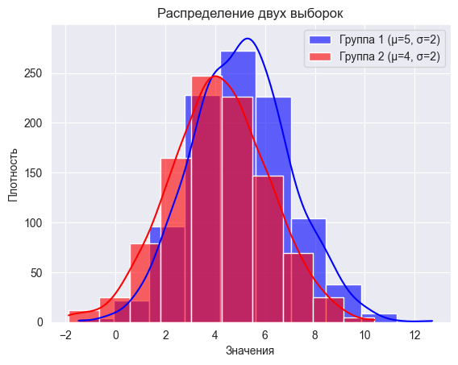

```python
# Гистограммы с KDE (параметр density=True делает гистограмму нормированной)
sns.histplot(far_group1, bins=10, kde=True, color='blue', label=f'Группа 1 (μ={mu_1}, σ={sigma_1})', alpha=0.6)
sns.histplot(far_group2, bins=10, kde=True, color='red', label=f'Группа 2 (μ={mu_2}, σ={sigma_2})', alpha=0.6)

# Добавляем легенду и подписи
plt.legend()
plt.title("Распределение двух выборок")
plt.xlabel("Значения")
plt.ylabel("Плотность")
plt.grid(True)

# Показываем график
plt.show()
```

# Критерий Стьюдента для независимых выборок

$H_0: \mathbb{E}\xi_1 = \mathbb{E}\xi_2$

$H_1: \mathbb{E}\xi_1 \neq \mathbb{E}\xi_2$

1. Данные в каждой выборке должны быть нормально распределены
2. Дисперсии двух выборок должны быть равными

```python
t_stat, p_value = stats.ttest_ind(far_group1, far_group2)

print(f"T-статистика: {t_stat:.4f}, p-значение: {p_value:.4f}")
```

```
T-статистика: 10.1466, p-значение: 0.0000
```

```python
mu_3, sigma_3 = 5, 2
mu_4, sigma_4 = 4.9, 2

# Генерируем две выборки
near_group1 = np.random.normal(mu_3, sigma_3, size=n)
near_group2 = np.random.normal(mu_4, sigma_4, size=n)
```

```python
t_stat, p_value = stats.ttest_ind(near_group1, near_group2)

print(f"T-статистика: {t_stat:.4f}, p-значение: {p_value:.4f}")
```

```
T-статистика: 1.8178, p-значение: 0.0692
```

## U-критерий Манна-Уитни

$H_0: x, y \sim O$

$H_1: x \sim O, y \sim A$

1. Две выборки должны быть независимыми
2. Не требуется нормальность распределения
3. Выборки должны быть из распределений с одинаковой формой (т.е. без различий в дисперсиях).

```python
u_stat, p_value = stats.mannwhitneyu(far_group1, far_group2, alternative='two-sided')

print(f"U-статистика: {u_stat:.4f}, p-значение: {p_value:.4f}")
```

```
U-статистика: 623546.0000, p-значение: 0.0000
```

```python
u_stat, p_value = stats.mannwhitneyu(near_group1, near_group2, alternative='two-sided')

print(f"U-статистика: {u_stat:.4f}, p-значение: {p_value:.4f}")
```

```
U-статистика: 520953.0000, p-значение: 0.1047
```

## Критерий Колмогорова-Смирнова (KS-тест)

$H_0$: Оба распределения принадлежат одной и той же генеральной совокупности

$H_1$: Распределения различаются

1. Две выборки должны быть независимыми
2. Не требуется нормальность распределения

```python
ks_stat, p_value = stats.ks_2samp(far_group1, far_group2)

print(f"KS-статистика: {ks_stat:.4f}, p-значение: {p_value:.4f}")
```

```
KS-статистика: 0.1880, p-значение: 0.0000
```

```python
ks_stat, p_value = stats.ks_2samp(near_group1, near_group2)

print(f"KS-статистика: {ks_stat:.4f}, p-значение: {p_value:.4f}")
```

```
KS-статистика: 0.0430, p-значение: 0.3137
```

# Однофакторный дисперсионный анализ (ANOVA)

Этот критерий используется для сравнения средних значений более чем двух групп. Аналог t-критерия, но для нескольких групп.

$H_0$: Средние значения всех групп равны.

$H_1$: Хотя бы одна из групп отличается.

1. Группы должны быть независимыми.
2. Данные в каждой группе должны быть нормально распределены.
3. Дисперсии в группах должны быть примерно равными.

```python
# Генерируем три выборки с разными средними значениями
np.random.seed(42)
group1 = np.random.normal(50, 10, 30)
group2 = np.random.normal(55, 10, 30)
group3 = np.random.normal(60, 10, 30)

# ANOVA тест
f_stat, p_value = stats.f_oneway(group1, group2, group3)

print(f"F-статистика: {f_stat:.4f}, p-значение: {p_value:.4f}")
```

```
F-статистика: 12.2095, p-значение: 0.0000
```

```python
# Генерируем три выборки с похожими средними значениями
np.random.seed(42)
group1 = np.random.normal(50, 10, 30)
group2 = np.random.normal(51, 10, 30)
group3 = np.random.normal(49, 10, 30)

# ANOVA тест
f_stat, p_value = stats.f_oneway(group1, group2, group3)

print(f"F-статистика: {f_stat:.4f}, p-значение: {p_value:.4f}")
```

```
F-статистика: 0.2392, p-значение: 0.7877
```

# Тест Вилкоксона (Wilcoxon Signed-Rank Test)

Непараметрический аналог t-критерия для зависимых выборок. Используется, если сравниваем одну и ту же группу до и после воздействия (например, измерения до и после лечения).

$H_0$: Медианные значения до и после равны (изменений нет).

$H_1$: Медианные значения различаются.

Выборки должны быть зависимыми (например, измерения до/после).

Распределение разностей должно быть симметричным (но не обязательно нормальным).

```python
before = np.random.normal(50, 10, 15)
after = before + np.random.normal(2, 5, 15)  # Добавляем небольшой сдвиг

# Тест Вилкоксона
w_stat, p_value = stats.wilcoxon(before, after)

print(f"W-статистика: {w_stat:.4f}, p-значение: {p_value:.4f}")
```

```
W-статистика: 33.0000, p-значение: 0.1354
```

# Критерий Шапиро-Уилка

Один из самых популярных тестов на нормальность, особенно для маленьких выборок (n < 50-100).

$H_0: \xi \sim N$

$H_1: \xi \sim \overline{N}$

1. Чувствителен к выбросам
2. Плохо работает на больших выборках (n > 5000)

Можно использовать критерий Колмогорова-Смирнова, где одна из выборок будет сгенерирована из нормального распределения

# На реальных данных

```
     Height    Weight       Age  Sex  Race
1  5.148726  4.321431  2.862201    0     1
2  5.075299  3.742042  2.484907    1     0
3  4.846185  3.198427  2.294217    0     0
4  4.952144  3.443549  2.382628    1     0
5  5.078468  3.954375  2.571339    0     0
```

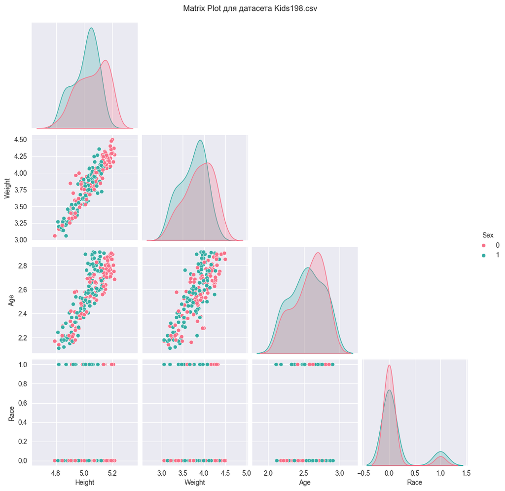

```python
# Загрузка данных
data = pd.read_csv('Kids198.csv', index_col=0)

# Исправленные преобразования единиц измерения
data['Height'] = np.log(data['Height'] * 2.54)  # Дюймы в сантиметры
data['Age'] = np.log(data['Age'] / 12)  # Месяцы в годы
data['Weight'] = np.log(data['Weight'] * 0.453592)  # Фунты в килограммы

# Вывод первых строк для проверки
print(data.head())

# Построение матрицы рассеяния
sns.pairplot(data, diag_kind='kde', corner=True, hue='Sex', palette='husl')

plt.suptitle('Matrix Plot для датасета Kids198.csv', y=1.02)
plt.show()
```